# EDA Laptop

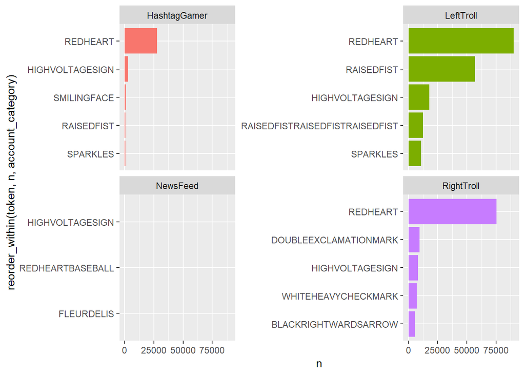

```r
tweets %>% filter(account_category %in% c("RightTroll", "LeftTroll", "NewsFeed", "HashtagGamer"),
                              emoji_bin=="Emoji") %>%
     group_by(account_category) %>% count(token) %>%
     top_n(5) %>%
     ungroup() %>%
     ggplot(aes(reorder_within(token, n, account_category),n, fill = account_category)) +
     geom_col(show.legend = F) + coord_flip() + scale_x_reordered() +
     facet_wrap(~account_category, ncol = 2, scales = "free_y")
```

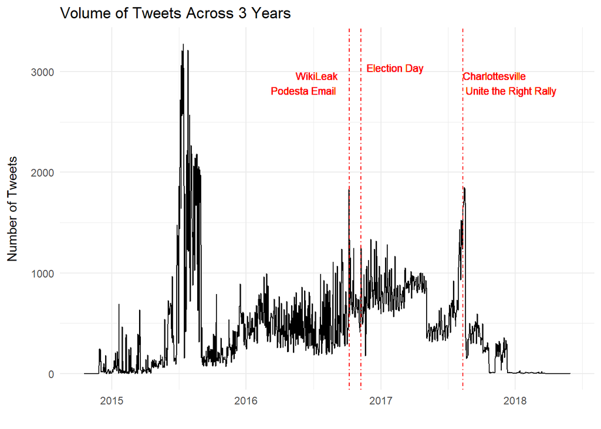

```r
tweets %>% distinct(tweet_id, .keep_all = T) %>%
  group_by(date = date(publish_date)) %>%
  filter(date >= as.Date("2014-06-01")) %>% count(date) %>%
  ungroup() %>%
  ggplot(aes(date, n)) + geom_line() + theme_minimal() +
    geom_vline(xintercept = as.Date("2016-11-08"), colour = "red", size = .5, linetype =4) +
    geom_text(aes(x=as.Date("2016-11-08"),y = 3000), label = "Election Day", size=3, angle=0, vjust=0,
              hjust=-0.1,  colour = "red") +
    geom_vline(xintercept = as.Date("2017-08-12"), colour = "red", size = .5, linetype =4) +
    geom_text(aes(x=as.Date("2017-08-12"),y = 3000),
              label = "Charlottesville \n Unite the Right Rally", size=3, angle=0,
              vjust=1,  hjust=0,  colour = "red") +
    geom_vline(xintercept = as.Date("2016-10-07"), colour = "red", size = .5, linetype =4) +
    geom_text(aes(x=as.Date("2016-10-07"),y = 3000),
              label = "WikiLeak \n Podesta Email", size=3, angle=0,
              vjust=1,  hjust=1.2,  colour = "red") +
    labs(title = "Volume of Tweets Across 3 Years", x = "", y = "Number of Tweets") +
    theme(axis.title.y = element_text(margin = margin(t = 0, r = 10, b = 0, l = 0)))
```

The flurry of activity in July and August of 2015 is the period of time when the Commercial account category was active.

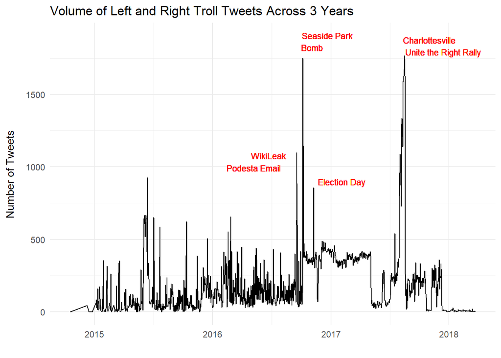

```r
tweets %>% filter(account_category %in% c("RightTroll", "LeftTroll")) %>% distinct(tweet_id, .keep_all = T) %>%
  group_by(date = date(publish_date)) %>%
  filter(date >= as.Date("2014-06-01")) %>% count(date) %>%
  ungroup() %>%
  ggplot(aes(date, n)) + geom_line() + theme_minimal() +
    geom_text(aes(x=as.Date("2016-11-08"),y = 875), label = "Election Day", size=3, angle=0, vjust=0,
              hjust=-0.1,  colour = "red") +
    geom_text(aes(x=as.Date("2017-08-12"),y = 1900),
              label = "Charlottesville \n Unite the Right Rally", size=3, angle=0,
              vjust=1,  hjust=0,  colour = "red") +
    geom_text(aes(x=as.Date("2016-10-07"),y = 1100),
              label = "WikiLeak \n Podesta Email", size=3, angle=0,
              vjust=1,  hjust=1.4,  colour = "red") +
    geom_text(aes(x=as.Date("2016-09-17"),y = 1800), label = "Seaside Park \n Bomb", size=3, angle=0, vjust=0,
              hjust=-0.1,  colour = "red") +
    labs(title = "Volume of Left and Right Troll Tweets Across 3 Years", x = "", y = "Number of Tweets") +
    theme(axis.title.y = element_text(margin = margin(t = 0, r = 10, b = 0, l = 0)))
```

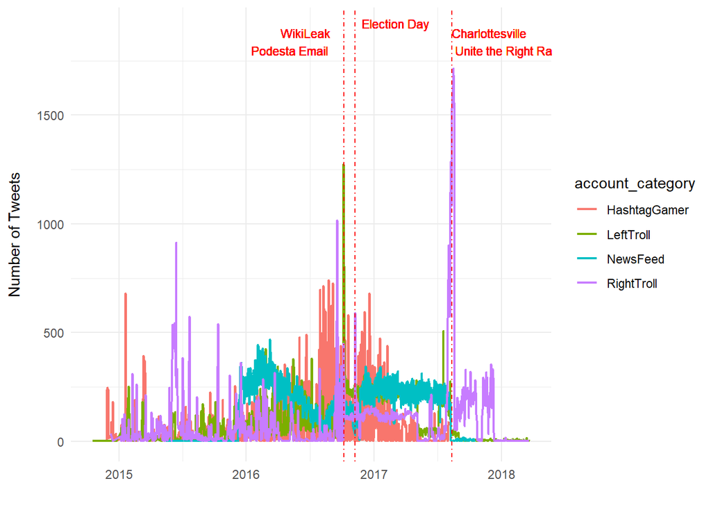

```r
tweets %>% distinct(tweet_id, .keep_all = T) %>%
  filter(account_category %in% c("RightTroll", "LeftTroll", "NewsFeed", "HashtagGamer")) %>%
  group_by(account_category, date = date(publish_date)) %>%
  filter(date >= as.Date("2014-06-01")) %>% count(date) %>%
  ungroup() %>%
  ggplot(aes(date, n, colour= account_category)) + geom_line(size = 0.75) + theme_minimal() +
    geom_vline(xintercept = as.Date("2016-11-08"), colour = "red", size = .5, linetype =4) +
    geom_text(aes(x=as.Date("2016-11-08"),y = 1900), label = "Election Day", size=3, angle=0,
              vjust=0,  hjust=-0.1,  colour = "red") + labs(x = "", y = "Number of Tweets") +
    geom_vline(xintercept = as.Date("2017-08-12"), colour = "red", size = .5, linetype =4) +
    geom_text(aes(x=as.Date("2017-08-12"),y = 1900),
              label = "Charlottesville \n Unite the Right Rally", size=3, angle=0,
              vjust=1,  hjust=0,  colour = "red") +
    geom_vline(xintercept = as.Date("2016-10-07"), colour = "red", size = .5, linetype =4) +
    geom_text(aes(x=as.Date("2016-10-07"),y = 1900),
              label = "WikiLeak \n Podesta Email", size=3, angle=0,
              vjust=1,  hjust=1.2,  colour = "red") +
    theme(axis.title.y = element_text(margin = margin(t = 0, r = 10, b = 0, l = 0)))
```

```r
#Top days of tweets for RightTrolls
 tweets %>% distinct(tweet_id, .keep_all = T) %>%
   group_by(date = date(publish_date)) %>%
   filter(date >= as.Date("2014-06-01"), account_category=="RightTroll") %>% count(date, sort = T)
```

```
## # A tibble: 959 x 2
## # Groups:   date [959]
##    date           n
##    <date>     <int>
##  1 2017-08-16  1715
##  2 2017-08-17  1687
##  3 2017-08-15  1634
##  4 2017-08-14  1584
##  5 2017-08-18  1559
##  6 2017-08-13  1545
##  7 2017-08-12  1533
##  8 2017-08-09  1286
##  9 2017-08-10  1166
## 10 2017-08-08  1147
## # ... with 949 more rows
```

08/08/2017 - 08/18/2017 saw a massive spike in tweets for RighTrolls. Occured around the Chartlottesville Unite the Right Rally.

```r
#Top days of tweets for LeftTrolls
 tweets %>% distinct(tweet_id, .keep_all = T) %>%
   group_by(date = date(publish_date)) %>%
   filter(date >= as.Date("2014-06-01"), account_category=="LeftTroll") %>% count(date, sort = T)
```

```
## # A tibble: 1,018 x 2
## # Groups:   date [1,018]
##    date           n
##    <date>     <int>
##  1 2016-10-06  1276
##  2 2016-10-07   807
##  3 2017-07-18   509
##  4 2016-02-26   426
##  5 2016-07-07   381
##  6 2016-05-15   380
##  7 2016-03-31   344
##  8 2016-05-16   344
##  9 2016-12-10   319
## 10 2016-12-04   305
## # ... with 1,008 more rows
```

The top 2 days for amount of LeftTroll tweets is 10/06/2016 - 10/07/2016, right before the beginning of the WikiLeaks Podesta email release.

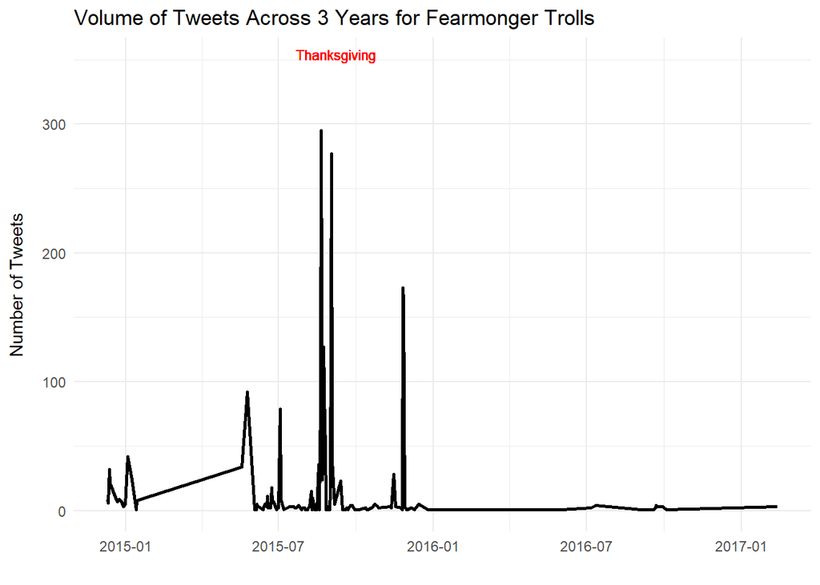

```r
tweets %>% distinct(tweet_id, .keep_all = T) %>% filter(account_category == "Fearmonger") %>%
  group_by(date = date(publish_date)) %>%
  filter(date >= as.Date("2014-06-01")) %>% count(date) %>%
  ungroup() %>%
  ggplot(aes(date, n)) + geom_line(size = 1) + theme_minimal() +
    geom_text(aes(x=as.Date("2016-11-08"),y = 350), label = "Thanksgiving", size=3, angle=0, vjust=0,
              hjust=5,  colour = "red") +
    labs(title = "Volume of Tweets Across 3 Years for Fearmonger Trolls", x = "", y = "Number of Tweets") +
    theme(axis.title.y = element_text(margin = margin(t = 0, r = 10, b = 0, l = 0)))
```

tf-idf

```r
total_words_subset <- tweets %>%
         filter(account_category %in% c("RightTroll", "LeftTroll", "NewsFeed", "HashtagGamer")) %>%
         count(account_category, token) %>% group_by(account_category) %>%
         summarise(total = sum(n))

tweets_grouptotals <- tweets %>% group_by(account_category) %>%
  count(token) %>%
  left_join(total_words_subset) %>%
  filter(account_category %in% c("RightTroll", "LeftTroll", "NewsFeed", "HashtagGamer"))
```

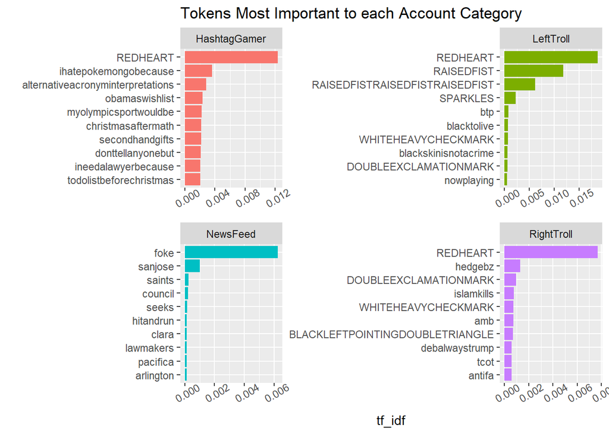

```r
tweets %>% filter(account_category %in% c("RightTroll", "LeftTroll", "NewsFeed", "HashtagGamer")) %>%
  group_by(account_category) %>%
  count(token) %>%
  bind_tf_idf(token, account_category, n) %>%
  arrange(desc(tf_idf)) %>% top_n(10) %>%
  ungroup() %>%
  ggplot(aes(reorder_within(token, tf_idf, account_category), tf_idf, fill = account_category)) +
  geom_col(show.legend = F) + coord_flip() + facet_wrap(~account_category, ncol = 2, scales = "free") +
  scale_x_reordered() + theme(axis.text.x = element_text(angle = 30, hjust = .5)) +
  labs(x = "") + ggtitle("Tokens Most Important to each Account Category")
```

“The idea of tf-idf is to find the important words for the content of each document by decreasing the weight for commonly used words and increasing the weight for words that are not used very much in a collection or corpus of documents”

Topic Modeling

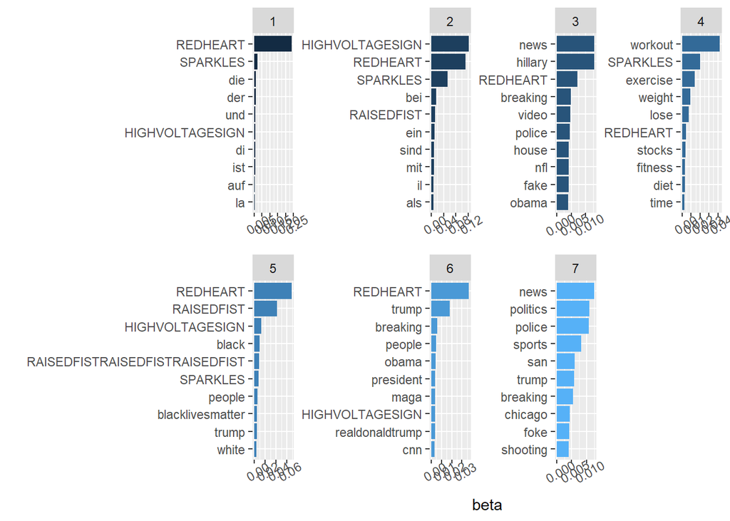

```r
tweets_count <- tweets %>% group_by(account_category) %>% count(token)
tweets_dtm <- tweets_count %>% cast_dtm(account_category, token, n)

tweets_lda7 <- LDA(tweets_dtm, k = 7, control = list(seed = 1234))
tweets_topics7 <- tidy(tweets_lda7, matrix = "beta")

tweets_topics7 %>% group_by(topic) %>% top_n(10, beta) %>% ungroup() %>%
  ggplot(aes(reorder_within(term, beta, topic), beta, fill = topic)) + geom_col(show.legend = F) +
  facet_wrap(~topic, scales = "free", ncol = 4) + scale_x_reordered() + coord_flip() +
  theme(axis.text.x = element_text(angle = 30, hjust = .5)) + labs(x = "")
```

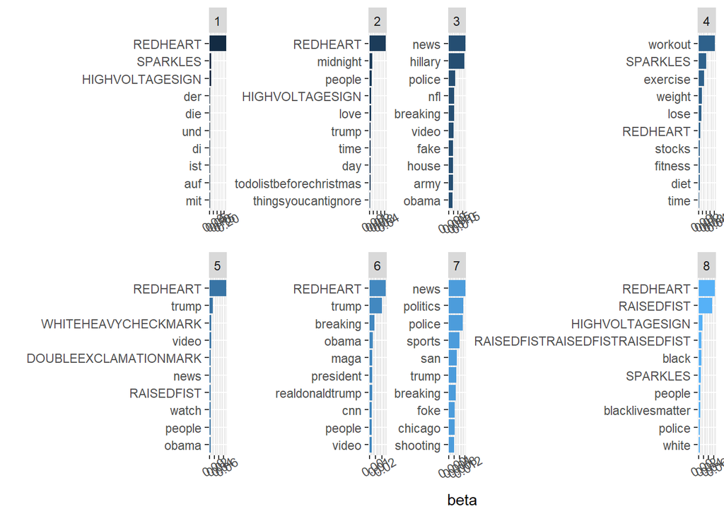

```r
tweets_lda8 <- LDA(tweets_dtm, k = 8, control = list(seed = 1234))
tweets_topics8 <- tidy(tweets_lda8, matrix = "beta")

tweets_topics8 %>% group_by(topic) %>% top_n(10, beta) %>% ungroup() %>%
  ggplot(aes(reorder_within(term, beta, topic), beta, fill = topic)) + geom_col(show.legend = F) +
  facet_wrap(~topic, scales = "free", ncol = 4) + scale_x_reordered() + coord_flip() +
  theme(axis.text.x = element_text(angle = 30, hjust = .5)) + labs(x = "")
```

```r
tidy(tweets_lda8, matrix = "gamma") %>% group_by(document) %>% top_n(2) %>% arrange(document, desc(gamma), document)
```

```
## # A tibble: 16 x 3
## # Groups:   document [8]
##    document     topic     gamma
##    <chr>        <int>     <dbl>
##  1 Commercial       4 1.000
##  2 Commercial       5 0.0000404
##  3 Fearmonger       6 0.724
##  4 Fearmonger       7 0.141
##  5 HashtagGamer     2 0.997
##  6 HashtagGamer     5 0.00217
##  7 LeftTroll        8 0.738
##  8 LeftTroll        5 0.239
##  9 NewsFeed         7 0.994
## 10 NewsFeed         3 0.00568
## 11 NonEnglish       1 1.000
## 12 NonEnglish       5 0.0000409
## 13 RightTroll       6 0.713
## 14 RightTroll       3 0.186
## 15 Unknown          5 0.628
## 16 Unknown          2 0.253
```

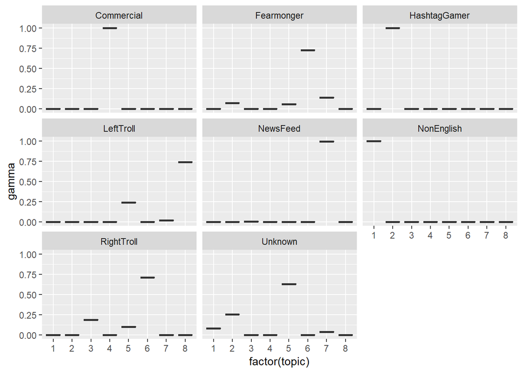

```r
tidy(tweets_lda8, matrix = "gamma") %>%
     mutate(category = reorder(document, gamma * topic)) %>%
     ggplot(aes(factor(topic), gamma)) +
     geom_boxplot() +
     facet_wrap(~ document)
```

“which topics are associated with each document. Can we put the chapters back together in the correct books? We can find this by examining the per-document-per-topic probabilities,  
(gamma)”